# MY472: Final assignment 2020/21

**Name:** Philip Porter

```r
# Suppress warnings for cleaner output (only implemented after finishing writing and editing script)
options(warn = -1)

# Load packages
suppressMessages(library(tidyverse))
suppressMessages(library(rvest))
suppressMessages(library(rtweet))
suppressMessages(library(quanteda))
suppressMessages(library(httr))
suppressMessages(library(jsonlite))
suppressMessages(library(DBI))
suppressMessages(library(RSQLite))
suppressMessages(library(countrycode))
suppressMessages(library(zoo))
suppressMessages(library(ggthemes))
```

### Exercise 1 (5 points)

Using the file `posts.csv` in this repo (the sample of 10,000 public Facebook posts by members of the US congress from 2017 which we also used in week 8), solve the following with `dplyr`:

- Do not consider posts with zero likes.
- Compute the comment to like ratio for each post (i.e. comments_count / likes_count).
- Compute the average comment to like ratio for each politician (screen_name).
- Subtract the corresponding politician’s average comment to like ratio from the comment to like ratio of each post. This allows to approximate how much higher or lower than usual the comment to like ratio of a post was.
- Sort the result in descending order of the de-meaned comment to like ratios.
- Report the screen name and value of the 10 posts with the highest value of the de-meaned comment to like ratio.

**The top 10 posts in terms of de-meaned comment-to-like ratio were posted by the following screen names (followed by de-meaned comment-to-like ratio of post)**

**1) susancollins, 15.89**

**2) CongresswomanSheilaJacksonLee, 15.83**

**3) senatortoomey, 11.55**

**4) RepClaudiaTenney, 10.05**

**5) SenDuckworth, 8.46**

**6) RepJoeBarton, 8.20**

**7) RepMullin, 7.02**

**8) RepMikeBishop, 6.63**

**9) AndyHarrisMD, 6.57**

**10) CongressmanAlexMooney, 6.23**

```r
# Load the sample of Facebook posts
posts <- read.csv("data/posts.csv", stringsAsFactors = FALSE)

# Filter out posts with zero likes
posts <- posts %>%
  filter(likes_count != 0)

# Add comment to like ratio for each post
posts <- posts %>%
  mutate(comment_like_ratio = comments_count / likes_count)

# Stop next step from triggering message about automatic ungrouping
options(dplyr.summarise.inform = FALSE)

# Make new data frame with each politician's average comment to like ratio (CLR)
politicians <- posts %>%
  group_by(screen_name) %>%
  summarise(mean(comment_like_ratio)) %>%
  rename("avg_clr" = "mean(comment_like_ratio)")

# Add average CLR to 'posts' by joining the two data frames
posts <- inner_join(posts, politicians, by = "screen_name")

# Subtract politicians' average CLR from CLR of each post to get de-meaned CLR
posts <- posts %>%
  mutate(demeaned_clr = comment_like_ratio - avg_clr)

# Sort 'posts' by de-meaned CLR
posts <- posts %>%
  arrange(desc(demeaned_clr))

# Show screen name and value for posts with top 10 de-meaned CLR value
posts %>%
  select(screen_name, demeaned_clr) %>%
  head(10)
```

```
##                      screen_name demeaned_clr
## 1                   susancollins    15.893685
## 2  CongresswomanSheilaJacksonLee    15.834072
## 3                  senatortoomey    11.545828
## 4               RepClaudiaTenney    10.046185
## 5                   SenDuckworth     8.462815
## 6                   RepJoeBarton     8.201462
## 7                      RepMullin     7.015464
## 8                  RepMikeBishop     6.627162
## 9                   AndyHarrisMD     6.568839
## 10         CongressmanAlexMooney     6.225182
```

### Exercise 2 (7 points)

When scraping websites, it is not always necessary to find out the CSS selector or XPath of elements that are of interest. With your knowledge of regular expressions, you can sometimes scrape the full HTML content of a website and extract all relevant parts from it with a regular expression in one go. This exercise is about such a case.

1. With the `rvest` package, scrape the HTML content of the LSE’s graduate course site `https://www.lse.ac.uk/resources/calendar/courseGuides/graduate.htm` and transform it into one large text with `html_text()`. (Do **not** use the `html_nodes()` function or any selectors)
2. With `stringr` from the `tidyverse`, define and use a regular expression that extracts only the course codes from this text. In the end you should store the course codes in a character vector (not the names of the courses, just their codes have to be extracted with the regular expression).
3. Print the first 200 course codes, this should be a vector starting with “AC411, AC412, AC415, …”
4. How many unique graduate course codes are there in total?

**There are 1072 unique graduate course codes**

```r
### PART A) ###

# Save website as 'lse'
lse <- "https://www.lse.ac.uk/resources/calendar/courseGuides/graduate.htm"

# Parse url
courses_html <- read_html(lse)

# Transform into text
courses_text <- html_text(courses_html)


### PART B) ###

# Extract course codes with regex
course_codes <- str_extract_all(courses_text, "[A-Z]{2}4[A-Z0-9]{2,3}")

# Store as character vector
course_codes <- unlist(course_codes)


### PART C) ###

# Print first 200 course codes
print(paste(course_codes[1:200], collapse = ", "))
```

[output not shown]

```r
### PART D) ###

# Find number of unique graduate course codes
length(unique(course_codes))
```

```
## [1] 1072
```

### Exercise 3 (15 points)

Using the Twitter streaming API, collect tweets for some hours or a couple of days with a filter of one or more words you choose related to `lockdown`. Store these tweets in a file such that you do not have to collect them again later when knitting the document. Then download the following sentiment dictionary from the [University of Pittsburgh](https://mpqa.cs.pitt.edu/lexicons/subj_lexicon/) (MPQA), and process the data such that all positive words are stored in a character vector and all negative words are stored in another character vector. Make sure to delete all duplicated words within each vector. Afterwards use `quanteda` for the textual analysis. You can build a corpus and document-feature matrices (dfms) based on the tweet texts you collected and you can create a `quanteda` (sentiment) dictionary with positive and negative sentiment words based on your two vectors. Then find all tweets which contain at least one of the sentiment keywords. For simplicity, label every tweet as `positive` that contains at least one of the positive keywords and none of the negative ones, and every tweet as `negative` that contains at least one of the negative keywords and none of the positive ones. For tweets with both types of keywords, label tweets as positive if they contain more positive keywords and as negative if they contain more negative keywords. All tweets without keywords are labeled as neutral, and tweets containing both kinds of keywords in equal numbers are assumed to be neutral as well.

1. How many unique positive and negative sentiment keywords do your two sentiment word vectors contain after you have loaded and cleaned the MPQA data? Also print the first 10 words from each vector.

**After cleaning, the positive word vector contains 2304 unique keywords, while the negative word vector contains 4152 unique words**

2. How many lockdown related tweets did you collect and which keyword(s) did you use to filter?

**369,532 tweets were collected over the course of Jan 4th 2021, the day that a new national lockdown was announced in the UK, using the keywords ‘lockdown’ and ‘restrictions’ to filter**

3. Through your textual analysis, what share of all lockdown related tweets do you find as having negative sentiment, what share as positive sentiment?

**23.7% of the collected tweets were classified as having negative sentiment, while 42.5% were classified as having positive sentiment**

4. Visualise the content of all positive lockdown tweets in a word cloud and the content of all negative lockdown tweets in another word cloud. To make this more informative, do not depict the following words: i) stopwords, ii) the filter words you used to defined lockdown tweets, and iii) the sentiment words (because these words will be contained in the tweets by construction and might otherwise bias the word clouds).

Hint: The sentiment list comes in a somewhat nonstandard text based file `subjclueslen1-HLTEMNLP05.tff` - have a look at it in your text editor. Such issues are very frequent when working with data, so it is good to study how to solve them as well. One approach is to load the file specifying that the column delimiter is a space, i.e. `read.csv("subjclueslen1-HLTEMNLP05.tff", sep = " ", header = FALSE)`. The only columns that you need afterwards contain words (`word1`) and sentiment (`priorpolarity`). You can keep only these two columns from the data frame and replace “word1=” and “priorpolarity=” in each line with an empty string "“. Afterwards you can create your two character vectors with unique positive and negative sentiment words. A different approach would be to open the file `subjclueslen1-HLTEMNLP05.tff` in a text editor and find-replace”type=“,”len=“,”word1=“,”pos1=“,”stemmed1=“,”priorpolarity=“, etc. all with”" before saving the file again and loading it into R.

Note: If your two word clouds are not too different, the likely reason is that we are classifying tweets into positive and negative with a very simple heuristic here (i.e. by checking whether they contain one or more keywords from the dictionary).

*The solution of using nested ‘if_else’ functions to add a sentiment column to the ‘tw_sent’ tibble was inspired by this slide by David Ranzolin (2015): https://rstudio-pubs-static.s3.amazonaws.com/116317_e6922e81e72e4e3f83995485ce686c14.html#/6 (retrieved on Jan 8th 2021)*

```r
### Authentication
# load("authentication.rda")

# twitter_token <- create_token(app = "itsthefinalassignment",
#                             consumer_key = authentication$consumer_key,
#                             consumer_secret = authentication$consumer_secret,
#                             access_token = authentication$access_token,
#                             access_secret = authentication$token_secret)

### Collect tweets related to lockdown (in the English language, since the sentiment dictionary is in English)
# stream_tweets(q = "lockdown, restrictions", timeout = (60 * 60 * 9), parse = FALSE, file_name = "tweets", language = "en")

# Load sentiment dictionary
mpqa <- read.csv("subjclueslen1-HLTEMNLP05.tff", sep = " ", header = FALSE)

# Select and rename columns of sentiment dictionary data frame
mpqa <- mpqa %>%
  select(V3, V6) %>%
  rename("word" = "V3", "sentiment" = "V6")

# Remove 'word1=' and 'priorpolarity=' from elements
mpqa$word <- gsub("word1=", "", mpqa$word)
mpqa$sentiment <- gsub("priorpolarity=", "", mpqa$sentiment)

# Create vectors with positive and negative words respectively
pos_words <- mpqa$word[mpqa$sentiment == "positive"]
neg_words <- mpqa$word[mpqa$sentiment == "negative"]

# Remove duplicate words from vectors
pos_words <- unique(pos_words)
neg_words <- unique(neg_words)

### Load collected tweets (original parsing commented out, as it took very long)
# tweets <- parse_stream("tweets.json")
# save(tweets, file = "tweets.Rda")
load("tweets.Rda")

# Create a corpus of texts from tweets
tw_corpus <- corpus(tweets$text)

# Create dfm based on corpus
tw_dfm <- dfm(tw_corpus, remove_punct = TRUE)
head(tw_dfm)
```

```
## Document-feature matrix of: 6 documents, 158,895 features (100.0% sparse).
##        features
## docs    i know sometimes we get criticised for moving fast but
##   text1 1    1         1  1   1          1   1      1    1   1
##   text2 0    0         0  0   1          0   0      0    0   0
##   text3 0    1         0  0   0          0   1      0    0   0
##   text4 0    0         0  0   0          0   1      0    0   0
##   text5 0    0         0  0   0          0   1      0    0   0
##   text6 0    0         0  0   0          0   1      0    0   0
## [ reached max_nfeat ... 158,885 more features ]
```

```r
# Create quanteda sentiment dictionary
sent_dict <- dictionary(list(positive = pos_words, negative = neg_words))

# Find number of positive and negative words for each tweet
tw_sent <- dfm_lookup(tw_dfm, sent_dict)

# Find the difference between number of positive and negative words for each tweet and add to sentiment tibble as a sentiment score
tw_sent <- suppressWarnings(as_tibble(tw_sent))
tw_sent <- tw_sent %>%
  mutate(sent_score = positive - negative)

# Add a verdict of each tweet's overall sentiment
tw_sent <- tw_sent %>%
  mutate(sentiment = if_else(sent_score > 0, "positive",
                             if_else(sent_score == 0, "neutral", "negative")))


### PART A) ###

# Find number of unique positive words and negative words in sentiment vectors
length(pos_words)
```

```
## [1] 2304
```

```r
length(neg_words)
```

```
## [1] 4152
```

```r
# Print first 10 words from each vector (as data frames for cleaner output)
head(as.data.frame(pos_words), 10)
```

```
##        pos_words
## 1       abidance
## 2          abide
## 3      abilities
## 4        ability
## 5           able
## 6          above
## 7  above-average
## 8         abound
## 9        absolve
## 10      abundant
```

```r
head(as.data.frame(neg_words), 10)
```

```
##      neg_words
## 1    abandoned
## 2  abandonment
## 3      abandon
## 4        abase
## 5    abasement
## 6        abash
## 7        abate
## 8     abdicate
## 9   aberration
## 10       abhor
```

```r
### PART B) ###

# Find number of tweets collected (NB: Some tweets may be duplicates if they were posted multiple times. To get number of tweets with unique texts, 'length(unique(tweets$text))' should be used as the innermost argument)
nrow(unique(tweets))
```

```
## [1] 369532
```

```r
### PART C) ###

# Find share of positive tweets
length(tw_sent$sentiment[tw_sent$sentiment == "positive"]) / 369532
```

```
## [1] 0.4254246
```

```r
# Find share of negative tweets
length(tw_sent$sentiment[tw_sent$sentiment == "negative"]) / 369532
```

```
## [1] 0.2371324
```

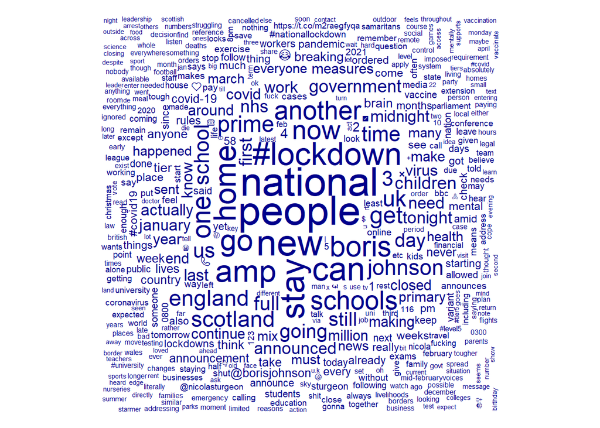

```r
### PART D) ###

# Create corpus of only positive tweets
pos_corpus <- tw_sent %>%
  add_column(tw_corpus) %>%
  rename(text = tw_corpus) %>%
  filter(sentiment == "positive")

pos_corpus <- corpus(pos_corpus$text)

# Create dfm from only positive tweets (when removing sentiment words, only positive words were removed, as the negative words aren't necessarily in the tweets)
pos_dfm <- dfm(pos_corpus, remove = c(stopwords("english"), "lockdown", "restrictions", pos_words), remove_punct = TRUE)

# Create word cloud from positive tweets
suppressWarnings(textplot_wordcloud(pos_dfm))
```

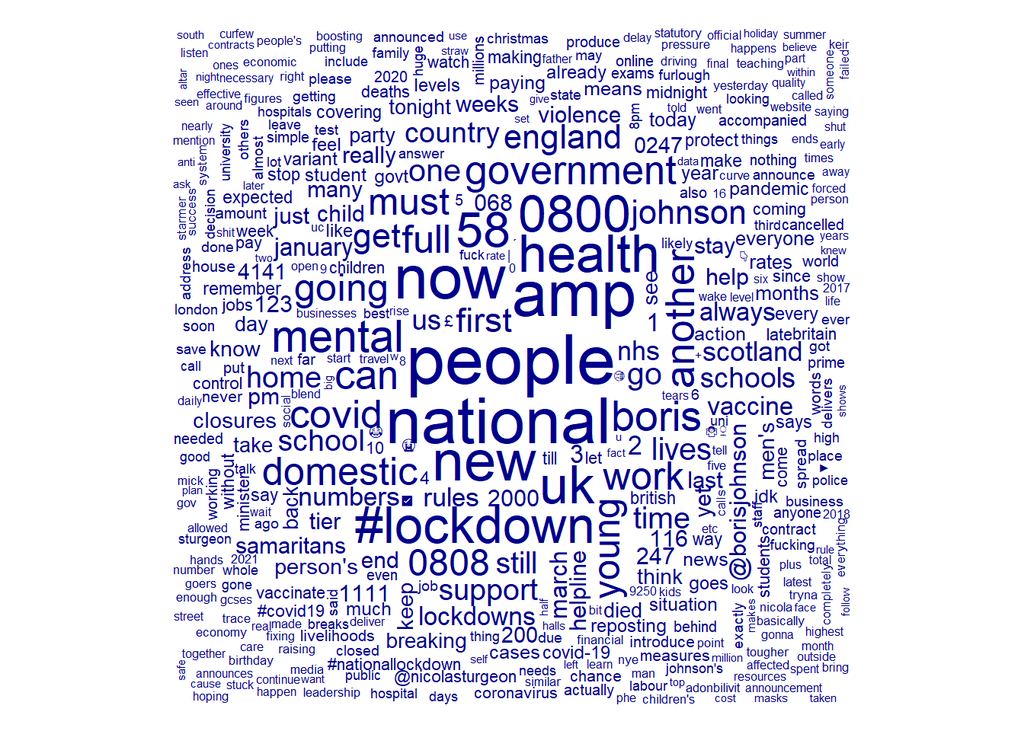

```r
# Create corpus of only negative tweets
neg_corpus <- tw_sent %>%
  add_column(tw_corpus) %>%
  rename(text = tw_corpus) %>%
  filter(sentiment == "negative")

neg_corpus <- corpus(neg_corpus$text)

# Create dfm from only negative tweets
neg_dfm <- dfm(neg_corpus, remove = c(stopwords("english"), "lockdown", "restrictions", neg_words), remove_punct = TRUE)

# Create word cloud from positive tweets
suppressWarnings(textplot_wordcloud(neg_dfm))
```

### Exercise 4 (10 points)

The [Archive API of the NYT](https://developer.nytimes.com/docs/archive-product/1/overview) allows to download all articles from a given month (up to one paragraph length). While you could use e.g. the `rtweet` package in Exercise 3, the goal now is to create an own function for the NYT API into which a user could input a year, e.g. 1918, and obtain a single concatenated data frame/tibble containing all data from this year.

1. The data frame which the function returns should additionally contain two new columns: One named `headline_processed` and one named `texts_combined`. While the original headline column contains different pieces of information, the `headline_processed` column should be of type character and only contain the main text of the headline. The `text_combined` column should also be of type character and contain the concatenation of a row’s `headline_processed` and `snippet` separated by a space " ". Lastly, before returning the data frame, the function should delete the columns `headline`, `byline`, `multimedia`, and `keywords`. These are not required in the analysis here and contain nested lists and data frames which can make writing the files to disk as `.csv` later unnecessarily complicated.
2. Use your function to download all article data for 1918 and 1919 in two data frame which will be used in later exercises.
3. Print the first 10 rows of each of your two data frames for 1918 and 1919 selecting only the three columns `id_`, `headline_processed`, and `text_combined`. Also print out the total amount of columns and rows of each of the two data frames.
4. Store the two data frames as `.csv` files on your computer such that you can load them later without downloading the data again. You can e.g. use the function `write_csv()` from the `readr` package.

Hint: Briefly read up about the rate limits of the NYT API in the [FAQ](https://developer.nytimes.com/faq) and pause your script for some seconds before downloading the next month in the function.

```r
# Authentication
load("nyt_key.rda")


### PART A) ###

# Create function
return_yearly_archive_data <- function(year) {

  # Create blank tibble
  df <- tibble()

  # Loop over months in a given year, downloading NYT article data from each month and storing it as a list
  for (month in seq(1:12)) {
    month <- GET(paste0("https://api.nytimes.com/svc/archive/v1/", year, "/", month, ".json?api-key=", nyt_key)) %>%
      content("text") %>%
      fromJSON()

    # Store the article data from the list in a tibble
    month <- month$response$docs %>%
      as_tibble()

    # Attach that month's tibble to the original tibble
    df <- bind_rows(df, month)

    # Pause script for 6 seconds in line with the API rate limit, before repeating the process for the next month
    Sys.sleep(6)
  }

  # Add and remove the instructed columns
  df <- df %>%
    mutate(headline_processed = headline$main) %>%
    mutate(text_combined = paste(headline_processed, snippet)) %>%
    select(-headline, -byline, -multimedia, -keywords)

  # Return the final tibble as the function output
  return(df)
}


### Part B) ###

# Download and store all article data from 1918 and 1919
nyt1918 <- return_yearly_archive_data(1918)
nyt1919 <- return_yearly_archive_data(1919)


### PART C) ###

# Print first 10 rows of selected columns for 1918
nyt1918 %>%
  select("_id", headline_processed, text_combined) %>%
  head(10)
```

```
## # A tibble: 10 x 3
##    `_id`            headline_processed              text_combined
##    <chr>            <chr>                           <chr>
##  1 nyt://article/0~ Will They Go 90 Miles?          "Will They Go 90 Miles? "
##  2 nyt://article/0~ MEET ROSENWALD'S OFFER.; $10,0~ "MEET ROSENWALD'S OFFER.; $~
##  3 nyt://article/0~ READY TO GATHER NEW TAX RETURN~ "READY TO GATHER NEW TAX RE~
##  4 nyt://article/0~ ARGENTINA TO SELL WHEAT.; Arra~ "ARGENTINA TO SELL WHEAT.; ~
##  5 nyt://article/0~ MENORAH THANKS ENGLAND; Britis~ "MENORAH THANKS ENGLAND; Br~
##  6 nyt://article/0~ BRITISH CASUALTIES FEWER.; Dec~ "BRITISH CASUALTIES FEWER.;~
##  7 nyt://article/0~ THE WOMAN VOTER AND THE NATION~ "THE WOMAN VOTER AND THE NA~
##  8 nyt://article/0~ WILSON BACKS LABOR LAWS.; Oppo~ "WILSON BACKS LABOR LAWS.; ~
##  9 nyt://article/0~ REFUSE $1,5000,000 LOAN.; Alvi~ "REFUSE $1,5000,000 LOAN.; ~
## 10 nyt://article/0~ SEVEN ALLIES SEND NEW YEAR GRE~ "SEVEN ALLIES SEND NEW YEAR~
```

```r
# Print first 10 rows of selected columns for 1919
nyt1919 %>%
  select("_id", headline_processed, text_combined) %>%
  head(10)
```

```
## # A tibble: 10 x 3
##    `_id`            headline_processed              text_combined
##    <chr>            <chr>                           <chr>
##  1 nyt://article/0~ "As to Fine Yarn Counts."       "As to Fine Yarn Counts. "
##  2 nyt://article/0~ "FINANCIAL MARKETS; Stocks Tur~ "FINANCIAL MARKETS; Stocks ~
##  3 nyt://article/0~ "Obituary 4 -- No Title"        "Obituary 4 -- No Title "
##  4 nyt://article/0~ "Obituary 6 -- No Title"        "Obituary 6 -- No Title "
##  5 nyt://article/0~ "START A HYLAN BOOM.; Mayor Pr~ "START A HYLAN BOOM.; Mayor~
##  6 nyt://article/0~ "Want Kaiser's Bell Removed."   "Want Kaiser's Bell Removed~
##  7 nyt://article/0~ "BOXER DIES OF INJURIES.; Bout~ "BOXER DIES OF INJURIES.; B~
##  8 nyt://article/0~ "CONSIDER RAIL CONTROL.; Warfi~ "CONSIDER RAIL CONTROL.; Wa~
##  9 nyt://article/0~ "FAST WALKERS IN MATCH.; Remer~ "FAST WALKERS IN MATCH.; Re~
## 10 nyt://article/0~ "Drug Trading Is Light."        "Drug Trading Is Light. "
```

```r
# Print numbers of rows and columns for each of the two data frames
print(paste("nyt1918 has", nrow(nyt1918), "rows and", ncol(nyt1918), "columns."))
```

```
## [1] "nyt1918 has 73161 rows and 17 columns."
```

```r
print(paste("nyt1919 has", nrow(nyt1919), "rows and", ncol(nyt1919), "columns."))
```

```
## [1] "nyt1919 has 78303 rows and 17 columns."
```

```r
### PART D) ###

# Save both data frames as CSV files
write_csv(nyt1918, "nyt1918.csv")
write_csv(nyt1919, "nyt1919.csv")
```

### Exercise 5 (10 points)

Use the NYT Archive data for 1918 which you downloaded in Exercise 4 to replicate the following plot as closely as possible. Also compute/print out the total observations/texts on which each of your three density estimates are based.

Hint: Before beginning with the plot, you will first need do some computations with the downloaded data (also see the plot annotations for clues).

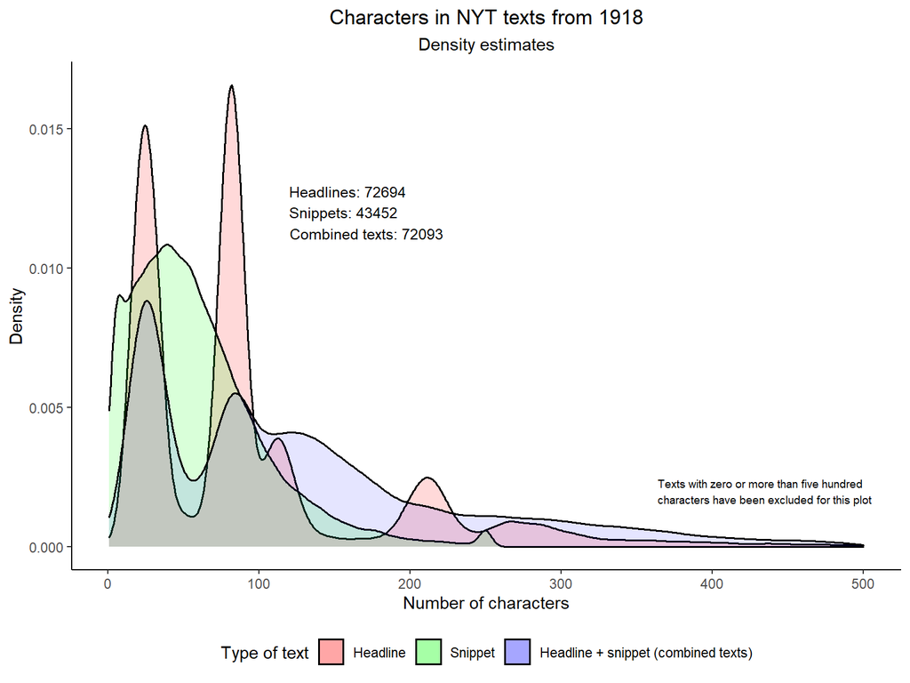

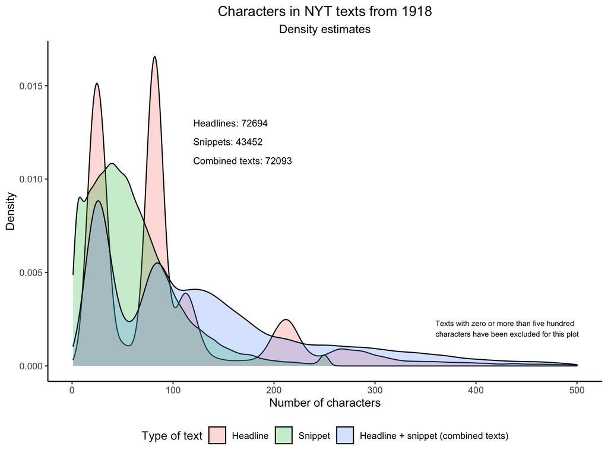

```r
# Read in data from CSV file
nyt1918 <- read.csv("nyt1918.csv", stringsAsFactors = FALSE)

# Add variables for number of characters to article data
nyt1918 <- nyt1918 %>%
  mutate(nchar_headline = nchar(headline_processed), nchar_snippet = nchar(snippet), nchar_combined = nchar(text_combined))

# Create plot
ggplot() +

  # Add a density plot for each of the three nchar variables
  geom_density(data = nyt1918[nyt1918$nchar_headline > 0 & nyt1918$nchar_headline <= 500, ], aes(x = nchar_headline, fill = "Headline"), alpha = 0.15, size = 0.6) +
  geom_density(data = nyt1918[nyt1918$nchar_snippet > 0 & nyt1918$nchar_snippet <= 500, ], aes(x = nchar_snippet, fill = "Snippet"), alpha = 0.15, size = 0.6) +
  geom_density(data = nyt1918[nyt1918$nchar_combined > 0 & nyt1918$nchar_combined <= 500, ], aes(x = nchar_combined, fill = "Headline + snippet (combined texts)"), alpha = 0.1, size = 0.6) +

  # Add annotation in bottom right corner
  annotate("text", x = 435, y = 0.002, label = "Texts with zero or more than five hundred   \ncharacters have been excluded for this plot", size = 2.5) +

  # Add central annotation, pasting in the number of headlines, snippets and combined texts
  annotate("text", x = 170, y = 0.012, label = paste0("Headlines: ", length(nyt1918$headline_processed[nchar(nyt1918$headline_processed) > 0 & nchar(nyt1918$headline_processed) <= 500]), "        \nSnippets: ", length(nyt1918$snippet[nchar(nyt1918$snippet) > 0 & nchar(nyt1918$snippet) <= 500]), "          \n Combined texts: ", length(nyt1918$text_combined[nchar(nyt1918$text_combined) > 0 & nchar(nyt1918$text_combined) <= 500])), size = 3.25) +

  # Add colours and legend to plot
  scale_fill_manual(values = c("Headline" = "red", "Snippet" = "green", "Headline + snippet (combined texts)" = "blue"), breaks = c("Headline", "Snippet", "Headline + snippet (combined texts)"), name = "Type of text") +

  # Add title, subtitle and axis titles
  labs(title = "Characters in NYT texts from 1918", subtitle = "Density estimates") +
  xlab("Number of characters") +
  ylab("Density") +

  # Set theme and adjust title, subtitle and legend positions
  theme_classic() +
  theme(plot.title = element_text(hjust = 0.5), plot.subtitle = element_text(hjust = 0.5), legend.position = "bottom")
```

### Exercise 6 (8 points)

Create an SQLite database called `fb-small.sqlite` and connect to it with the `DBI` package. Store the file `posts.csv` in the database as a table `posts`. The table may only contain the original information from `posts.csv`, all computations in this exercise have to be done with SQL.

1. With a **single** SQL query through `DBI`, try to replicate the outcome from Exercise 1, i.e. the query should return the same 10 highest de-meaned comment to like ratios with screen names.
2. Assuming that the posts table was a collection in a Mongo database and each row in it a document, write a MongoDB query to compute only the average comment to like ratio for each politician (no de-meaning required here, just the average comment to like ratio for each screen_name is sufficient for this part). You can write this MongoDB query as plain text below, no need to create a Mongo database and connect to it via R.

*The SQL query in part a) was inspired by the code in this question from ‘mikesol’ (2014): https://stackoverflow.com/questions/24257066/sql-legality-of-including-ungrouped-columns-in-group-by-statement (retrieved on Jan 11th 2021)*

```r
# Set up SQLite database
db <- dbConnect(SQLite(), "data/fb-small.sqlite")

# Load the FB data
posts <- read.csv("data/posts.csv", stringsAsFactors = FALSE)

# Add the FB data as a table to SQLite db
dbWriteTable(db, "posts", posts, overwrite = TRUE)


### PART A) ###

# Query db to return screen name and value for posts with top 10 de-meaned CLR. This is done by creating a temporary table where screen names are grouped and the average CLR for each is calculated. That table is then joined with the original table so the de-meaned CLR of each post can be calculated.
dbGetQuery(db, "SELECT
                  posts.screen_name,
                  1.0 * comments_count / likes_count - average_clr AS demeaned_clr
                FROM
                  (SELECT screen_name, AVG(1.0 * comments_count / likes_count) AS average_clr
                    FROM posts
                    GROUP BY screen_name)
                  AS posts_grouped
                  INNER JOIN posts
                  ON posts_grouped.screen_name = posts.screen_name
                ORDER BY demeaned_clr DESC LIMIT 10")
```

```
##                      screen_name demeaned_clr
## 1                   susancollins    15.893685
## 2  CongresswomanSheilaJacksonLee    15.834072
## 3                  senatortoomey    11.545828
## 4               RepClaudiaTenney    10.046185
## 5                   SenDuckworth     8.462815
## 6                   RepJoeBarton     8.201462
## 7                      RepMullin     7.015464
## 8                  RepMikeBishop     6.627162
## 9                   AndyHarrisMD     6.568839
## 10         CongressmanAlexMooney     6.225182
```

```r
# Close connection to database
dbDisconnect(db)
```

*Mongo DB query for the average comment to like ratio:*

**"db.posts.aggregate( [ { $group:**

**{ _id: ”$screen_name",**

**avgCLR: { $avg: { $divide: [ “$comments_count”, “$likes_count” ] } }**

**}**

**} ] )" (outer quotation marks not part of query)**

### Exercise 7 (22 points)

In this exercise, the goal is to use two APIs to download data, to create a relational database `covid.sqlite`, and to visualise and discuss developments and properties of the current pandemic that you find interesting and noteworthy. You can use the covid and policy API from the University of Oxford https://covidtracker.bsg.ox.ac.uk/about-api and the Athena API from the World Health Organizsation https://www.who.int/data/gho/info/athena-api to download data. You can e.g. use the Oxford API to download time series of cases, deaths, or policy strengths, and the WHO Athena API to download other relevant information such as statistics and health indicators. For both APIs there exists plenty of documentation and examples on their websites.

Once you have downloaded your data from the APIs through code in R, the next step is to create a new SQLite database `covid.sqlite`and to store the data in two tables such that it avoids unnecessary redundancies (also see Hint 1 below). If important for your data organisation and analysis, you can add more tables unless they create redundancies, however, only the following two are required and the rest is an addition.

- A table `countries` which contains country specific data. One row could be one country, and columns could be different indicators (replace the column names “population”, “another indicator” etc. in the table below with the names of indicators that you decide to download). In this table, each country only has one line and each indicator only one column, i.e. record the indicator values only for one (ideally the latest available) point in time.

| country_code | country_name | population | another indicator | … |
| --- | --- | --- | --- | --- |
| UK | United Kingdom | 42 | 42 | … |
| FR | France | 42 | 42 | … |
| … | … | … | … | … |

- A table `time_series` storing time series information e.g. on confirmed cases, deaths, policy strength, etc. One row in this table could be a country-day or country-month observation. If some time series have lower frequencies, they would have NULL (NA) values in the rows where no data is available for them.

| country_code | date | cases | deaths | … |
| --- | --- | --- | --- | --- |
| UK | 2020-01-01 | 0 | 0 | … |
| UK | 2020-01-02 | 0 | 0 | … |
| UK | 2020-01-03 | … | … | … |
| … | … | … | … | … |

1. Study the two APIs and obtain data from them (**through R**) that you find interesting and need for your later analysis. After you processed the data in R, create a database and store the distinct tables in it (no need to store any data in the database that you do not need in the later analysis).
2. Run SQLs queries which return the first five rows and all columns of your tables (to give the reader a preview of what you have collected). Also run SQL queries to return the total amount of rows of your tables.
3. Run a query (or queries) with a join command to show that it is possible to join your tables. Return **only** the first five rows of the joined table, and also return the total number of rows in the joined table with a query.
4. Visualise the data you collected with `ggplot2` and feel free to also discuss it with the help of other approaches and packages if helpful. Note that once you have queried the relevant data for your analysis from the database you created in part c), you can do all subsequent analysis in R for this part d). This resembles that data is typically stored in databases, but after parts have been extracted for an analysis, is is usually further processed in software such as R.

Hint 1: The previous SQLite database in Exercise 6 contained a single table only because the purpose of the exercise was to run one query. Actual relational databases contain multiple tables by definition. Recall that the reason why data is split into different tables in relational databases is that these databases are meant to store data. Data which is split into different tables avoids redundancies and is thereby more space efficient for storage. Merging the above two tables and storing only a single table in the database, for example, would have repeated country specific indicators in every daily/monthly row and hence taken up unnecessary storage space. Also note, that e.g. the country name is only stored in the country table in the example as it is unnecessary to also be stored in the time series table (as these tables can simply be joined on the country code whenever necessary). When analysing or visualising data on the other hand, the relevant information will likely be joined and extracted from the database. Following this logic, when storing data in your database, avoid redundant information where possible. In part d), however, extract data frames from the database as the basis for your subsequent processing and analysis with `ggplot2` or other packages.

Hint 2: Your tables need a column on which they can be merged. If the different APIs return different country codes, you could e.g. use the `countrycode` package or equivalent to obtain standardised country codes.

Hint 3: If you choose to depict time series plots and the daily data of cases is too noisy, one approach is to use moving averages or other smoothed time series. In e.g. a 7 day moving average, the value of a given day can be computed as the average of the last six days and the current day.

Hint 4: The data returned by the Oxford API can become large as it contains information on many countries and days. The WHO API also includes many potential indicators and time series. Just focus on using and storing information on those countries and variables that you have decided to use in your later analysis.

**1) A regression analysis of the association between countries’ average policy stringency over the period and their number of hospital beds per 10k population. It would make sense, all else equal, for countries with less patient capacity to have stricter measures if they want to limit number of deaths during the pandemic. The regression showed a negative association between per capita hospital beds and average stringency. An additional hospital bed per 10k population was associated with a 0.23 point drop in average stringency on the Oxford Stringency Index. The association was statistically significant (P = 0.0002). An extended analysis could specify a model with more variables to see if the association still holds when holding other variables constant, but that seemed beyond the scope of this exercise, taking into account the further two pieces of analyses I did.**

**2) The creation of a new index which can be interpreted as a (somewhat crude) measure of the combined burden of the pandemic on a country’s population from the stringency of policies in addition to the disease itself. This measure, the Case-rate-Stringency Index, was made by converting average case rates to an index with range 0-50, halving the Stringency Index to range 0-50, and summing each country’s score on both to create their Case-rate-Stringency Index score with range 0-100. Since the highest ‘average daily cases per 100k population’ for the period (39.9, Luxembourg) coincided well with the highest average (halved) stringency score (42.5, Argentina), it seemed fitting to let the average case rate index score of 50 just correspond to 50 new cases per 100k population. Conveniently, that means the formula for the final index is just**

```
Case-rate-Stringency Index score = 'average daily new cases per 100k pop.' + ( 'average Stringency Index score' / 2 )
```

**This works well for the chosen period, but more work would be needed to create an index that is generalisable to periods with higher or lower average case rates. Higher scores on the index mean higher burden on the population in the form of cases and stringent policies. The three countries lowest on the the Case-rate-Stringency Index for the period were Mauritius, New Zealand and Seychelles (all very remotely-located countries), while the top three highest scorers were Panama, Luxembourg and Georgia (with USA a very close fourth). All 81 country scores are visualised in a map.**

*The solution for dealing correctly with dates in the for loop transforming the Oxford data to a tibble was partially inspired by the answer by Alexey Ferapontov (2015) here: https://stackoverflow.com/questions/31274536/strange-behavior-involving-dates-origin-must-be-supplied (retrieved on Jan 12th 2021)*

*The solution for converting NULLs in list to NA was inspired by the answer by ‘Marek’ (2010) here: https://stackoverflow.com/questions/2991514/prevent-unlist-to-drop-null-values (retrieved on Jan 13th 2021)*

*The solution for controlling the order of multiple legends using ggplot2 was found in ’kohske’s (2012) answer here: https://stackoverflow.com/questions/11393123/controlling-ggplot2-legend-display-order (retrieved on Jan 14th 2021)*

```r
### PART A) ###

# Download Oxford data from second half of 2020 and parse into list
oxf <- fromJSON("https://covidtrackerapi.bsg.ox.ac.uk/api/v2/stringency/date-range/2020-07-01/2020-12-31")

# Create blank tibble to store the data in
oxf_df <- tibble()

# Loop over each date in the list, turning that date's data into a tibble and appending it to the tibble above
for (date in seq(as.Date("2020-07-01"), as.Date("2020-12-31"), 1)) {
  day <- oxf$data[[format(as.Date(date, origin = "1970-01-01"))]] %>%
    transpose() %>%
    as_tibble()

  oxf_df <- bind_rows(oxf_df, day)
}

# Rename and reorder columns and discard those not needed
oxf_df <- oxf_df %>%
  select(country_code, date_value, conf_cases = confirmed, stringency)

# Unlist columns so that SQLite can handle them
for (i in seq(1, 4, 1)) {

  # Convert NULLs to NA so they aren't dropped when unlisting
  oxf_df[[i]][sapply(oxf_df[[i]], is.null)] <- NA

  # Unlist
  oxf_df[i] <- oxf_df[i] %>%
    unlist()
}

# Download overview of WHO indicator codes
who_lookup <- GET("https://apps.who.int/gho/athena/api/GHO/.json") %>%
  content("parsed")

# Create tibble that shows indicator name and code for each indicator
who_lookup <- who_lookup$dimension[[1]]$code %>%
  as_tibble(.name_repair = "minimal") %>%
  transpose() %>%
  as_tibble() %>%
  select(ind_name = display, ind_code = label)

# Find indicator code for indicators of interest
who_lookup[regexpr("Hospital beds \\(per 10 000 population\\)", who_lookup$ind_name) != -1, ] %>%
  unlist()
```

```
##                                                                       ind_name1
##                                         "Hospital beds (per 10 000 population)"
##                                                                       ind_name2
## "EXISTING GHO INDICATOR Hospital beds (per 10 000 population) (Health systems)"
##                                                                       ind_code1
##                                                                      "WHS6_102"
##                                                                       ind_code2
##                                                                    "GDO_q9x1_2"
```

```r
who_lookup[regexpr("Population \\(in thousands\\)", who_lookup$ind_name) != -1, ] %>%
  unlist()
```

```
##                          ind_name                          ind_code
## "Population (in thousands) total"                         "WHS9_86"
```

```r
who_lookup[regexpr("Current health expenditure \\(CHE\\) per capita in PPP int\\$", who_lookup$ind_name) != -1, ] %>%
  unlist()
```

```
##                                                  ind_name
## "Current health expenditure (CHE) per capita in PPP int$"
##                                                  ind_code
##                                 "GHED_CHE_pc_PPP_SHA2011"
```

```r
# Store the three indicator codes in a character vector for later use
ind_codes <- c("WHS6_102", "WHS9_86", "GHED_CHE_pc_PPP_SHA2011")

# Create function to download and clean WHO indicator data
who_ind_data <- function(indicator) {

  # Download the indicator data and store it as a list
  df <- fromJSON(paste0("http://apps.who.int/gho/athena/api/GHO/", indicator, ".json?profile=simple"))

  # Store the required indicator data in a tibble
  df <- df$fact %>%
    as_tibble() %>%
    flatten() %>%

    # Make sure only the latest year of indicator data for each country is included
    group_by(dim.COUNTRY) %>%
    filter(dim.YEAR == max(dim.YEAR)) %>%

    # Keep just country and indicator values
    select(country = dim.COUNTRY, Value) %>%

    # Remove rows that aren't countries
    filter(!is.na(country))

  return(df)
}

# Retrieve country data for indicator 'Hospital beds (per 10 000 population)'
who_beds <- who_ind_data(ind_codes[1]) %>%
  rename(beds_per_10k = Value)

# Retrieve country data for indicator 'Population (in thousands)'
who_pop <- who_ind_data(ind_codes[2]) %>%
  rename(pop_thousands = Value)

# Remove spaces in population values so they can be classed as numeric type later
who_pop$pop_thousands <- gsub(" ", "", who_pop$pop_thousands)

# Retrieve country data for indicator 'Current health expenditure (CHE) per capita in PPP int$'
who_h_e <- who_ind_data(ind_codes[3]) %>%
  rename(health_exp_percap = Value)

# Join data including only countries with data on all three indicators
who_joined <- who_pop %>%
  inner_join(who_beds, by = "country") %>%
  inner_join(who_h_e, by = "country") %>%

  # Add country codes, reorder columns and sort by country code
  mutate(country_code = countrycode(country, "country.name", "iso3c")) %>%
  select(country_code, everything()) %>%
  arrange(country_code)

# Convert indicator values to numeric type
for (i in seq(3, 5, 1)) {
  who_joined[[i]] <- as.numeric(who_joined[[i]])
}

# Set up SQLite database
cdb <- dbConnect(SQLite(), "data/covid.sqlite")

# Write tables with Oxford and WHO data to database
dbWriteTable(cdb, "countries", who_joined, overwrite = TRUE)
dbWriteTable(cdb, "time_series", oxf_df, overwrite = TRUE)


### PART B) ###

# Return first five rows of 'countries' table
dbGetQuery(cdb, "SELECT * FROM countries LIMIT 5")
```

```
##   country_code              country pop_thousands beds_per_10k
## 1          AFG          Afghanistan         34656          3.9
## 2          AGO               Angola         28813          8.0
## 3          ALB              Albania          2926         28.9
## 4          ARE United Arab Emirates          9270         13.8
## 5          ARG            Argentina         43847         49.9
##   health_exp_percap
## 1            186.41
## 2            164.71
## 3            697.30
## 4           3172.61
## 5           1989.64
```

```r
# Return first five rows of 'time_series' table
dbGetQuery(cdb, "SELECT * FROM time_series LIMIT 5")
```

```
##   country_code date_value conf_cases stringency
## 1          ABW 2020-07-01        103      47.22
## 2          AFG 2020-07-01      31826      78.70
## 3          AGO 2020-07-01        291      75.93
## 4          ALB 2020-07-01       2580      68.52
## 5          AND 2020-07-01        855      31.48
```

```r
# Return number of rows in 'countries' table
dbGetQuery(cdb, "SELECT COUNT(*) AS countries_rows FROM countries")
```

```
##   countries_rows
## 1            176
```

```r
# Return number of rows in 'time_series' table
dbGetQuery(cdb, "SELECT COUNT(*) AS time_series_rows FROM time_series")
```

```
##   time_series_rows
## 1            33559
```

```r
### PART C) ###

# Demonstrate that tables can be joined by returning time series of cases together with population data for all countries present in both tables
dbGetQuery(cdb, "SELECT time_series.country_code, country, date_value, conf_cases, pop_thousands
                 FROM time_series
                 INNER JOIN countries
                 ON time_series.country_code = countries.country_code
                 LIMIT 5")
```

```
##   country_code              country date_value conf_cases pop_thousands
## 1          AFG          Afghanistan 2020-07-01      31826         34656
## 2          AGO               Angola 2020-07-01        291         28813
## 3          ALB              Albania 2020-07-01       2580          2926
## 4          ARE United Arab Emirates 2020-07-01      49069          9270
## 5          ARG            Argentina 2020-07-01      67197         43847
```

```r
# Return number of rows in the joined table
dbGetQuery(cdb, "SELECT COUNT (*) AS joined_rows
                 FROM time_series
                 INNER JOIN countries
                 ON time_series.country_code = countries.country_code")
```

```
##   joined_rows
## 1       29750
```

```r
### PART D) ###

# Query relevant data
covid_df <- dbGetQuery(cdb, "SELECT
                                   time_series.country_code, country, date_value,
                                   conf_cases, stringency, pop_thousands, beds_per_10k, health_exp_percap
                                 FROM time_series
                                 INNER JOIN countries
                                 ON time_series.country_code = countries.country_code")


# Close connection to database
dbDisconnect(cdb)


# Create additional variables
covid_df <- covid_df %>%
  group_by(country_code) %>%

  # Daily new confirmed cases per 100k population
  mutate(new_cases_per_100k = (conf_cases - lag(conf_cases)) / (pop_thousands / 100)) %>%

  # Moving 7-day average new cases per 100k
  mutate(m7avg_per_100k = rollapplyr(new_cases_per_100k, 7, mean, align = "right", partial = TRUE)) %>%

  # Weekly reproduction number (Rw)
  mutate(rw = m7avg_per_100k / lag(m7avg_per_100k, 7))


# Turn scientific notation off
options(scipen = 999)


# Make data set for countries in top 50% of health expenditure per capita (case data is likely to be less reliable for countries with lower health expenditure)
covid_half <- covid_df %>%

  # Create variables for each country
  group_by(country_code) %>%
  summarise(
    country = first(country),

    # Average daily confirmed cases per 100k
    avg_case_rate = mean(new_cases_per_100k, na.rm = TRUE),

    # Average Rw (average based on daily moving Rw)
    avg_rw = mean(rw, na.rm = TRUE),

    # Average stringency level
    avg_strin = mean(stringency, na.rm = TRUE),

    # Add static variables
    beds_per_10k = first(beds_per_10k),
    health_exp_percap = first(health_exp_percap)) %>%

  # Add variable for Case-rate-stringency index
  mutate(case_rate_strin_index = avg_case_rate + avg_strin / 2) %>%

  #Remove Liberia. There seems to be a data entry mistake for Liberia, as their health expenditure per capita shows as ~20 times higher than their GDP per capita, but the rest of the countries look okay.
  filter(country != "Liberia") %>%

  # Filter for countries in top 50% for health expenditure
  filter(health_exp_percap >= median(health_exp_percap))


# Linear regression of average stringency as function of hospital beds per 10k
lm_covid <- lm(avg_strin ~ beds_per_10k, data = covid_half)
summary(lm_covid)
```

```
##
## Call:
## lm(formula = avg_strin ~ beds_per_10k, data = covid_half)
##
## Residuals:
##     Min      1Q  Median      3Q     Max
## -39.370  -6.847   1.722   7.234  31.401
##
## Coefficients:
##              Estimate Std. Error t value             Pr(>|t|)
## (Intercept)  65.12593    2.65584  24.522 < 0.0000000000000002 ***
## beds_per_10k -0.22907    0.05809  -3.944             0.000173 ***
## ---
## Signif. codes:  0 '***' 0.001 '**' 0.01 '*' 0.05 '.' 0.1 ' ' 1
##
## Residual standard error: 12.48 on 79 degrees of freedom
## Multiple R-squared:  0.1645, Adjusted R-squared:  0.1539
## F-statistic: 15.55 on 1 and 79 DF,  p-value: 0.0001725
```

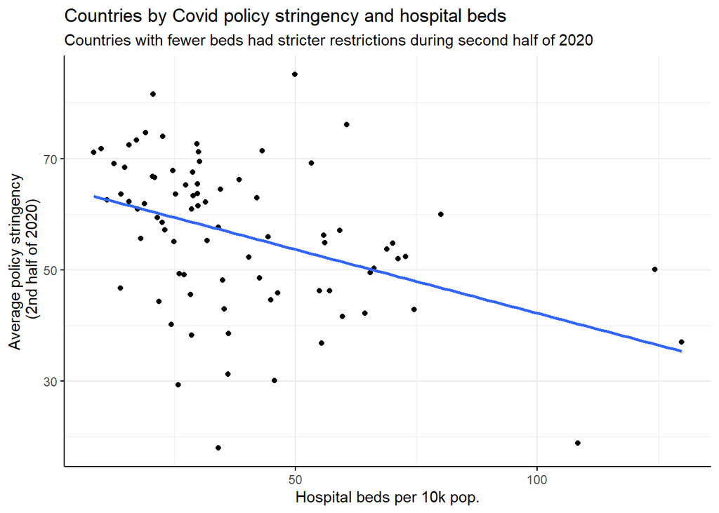

```r
# Plot the linear regression
ggplot(covid_half, aes(beds_per_10k, avg_strin)) +

  # Add scatter plot
  geom_point() +

  # Add regression line
  geom_smooth(method = "lm", se = FALSE) +

  # Add title, subtitles and axis titles
  labs(title = "Countries by Covid policy stringency and hospital beds",
       subtitle = "Countries with fewer beds had stricter restrictions during second half of 2020") +
  xlab("Hospital beds per 10k pop.") +
  ylab("Average policy stringency\n (2nd half of 2020)") +

  # Clean up theme
  theme_minimal() +
  theme(axis.line = element_line(), axis.ticks = element_line())
```

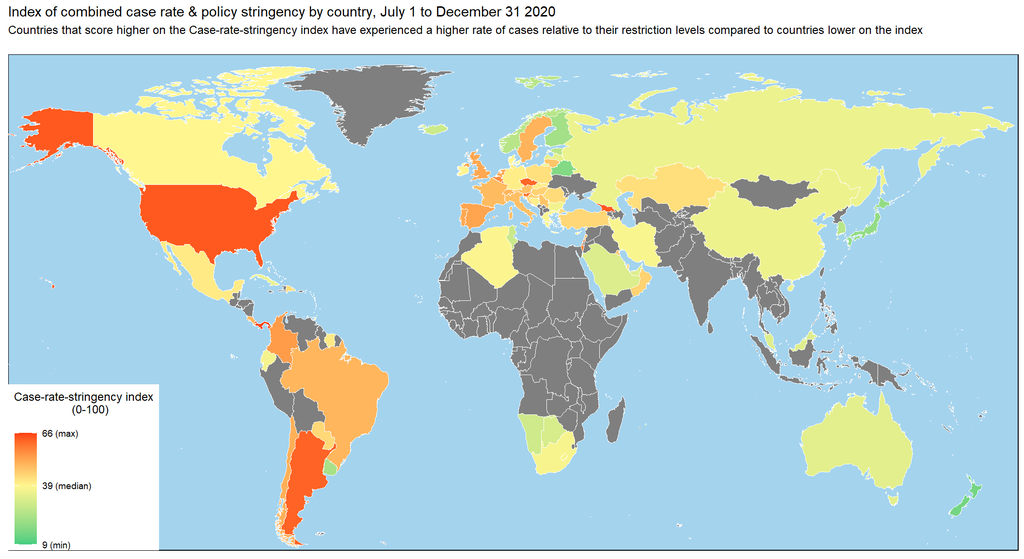

```r
# Create data frame for map visualisation
world_map <- map_data("world") %>%

  # Add country codes
  mutate(country_code = countrycode(region, "country.name", "iso3c")) %>%

  # Add country data incl. average covid stats to map data frame
  left_join(covid_half, by = "country_code")

# Create map visualisation of countries' Case-rate-stringency index scores
ggplot(world_map) +
  geom_map(aes(map_id = region, fill = case_rate_strin_index), map = world_map, color = "white", size = 0.1, ) +
  expand_limits(x = c(-155, 175), y = c(-50, 80)) +

  # Set fill to gradient as a function of country score
  scale_fill_gradient2(low = "seagreen3",
                       mid = "khaki1",
                       high = "red",
                       name = "Case-rate-stringency index\n                 (0-100)\n",
                       midpoint = median(world_map$case_rate_strin_index, na.rm = TRUE),

                       # Adjust legend
                       breaks = c(min(world_map$case_rate_strin_index, na.rm = TRUE),
                                  median(world_map$case_rate_strin_index, na.rm = TRUE),
                                  max(world_map$case_rate_strin_index, na.rm = TRUE)),
                       labels = c("9 (min)", "39 (median)", "66 (max)")) +

  # Adjust theme to map
  theme_map() +
  theme(panel.background = element_rect(fill = "lightskyblue2")) +

  # Add title and subtitle
  labs(title = "Index of combined case rate & policy stringency by country, July 1 to December 31 2020",
       subtitle = "Countries that score higher on the Case-rate-stringency index have experienced a higher rate of cases relative to their restriction levels compared to countries lower on the index\n")
```

```r
# Show the 5 countries with the highest burden from combined cases and stringency
covid_half %>%
  arrange(desc(case_rate_strin_index)) %>%
  select(country, avg_case_rate, avg_strin, case_rate_strin_index) %>%
  head(5)
```

```
## # A tibble: 5 x 4
##   country                  avg_case_rate avg_strin case_rate_strin_index
##   <chr>                            <dbl>     <dbl>                 <dbl>
## 1 Panama                            28.8      74.0                  65.8
## 2 Luxembourg                        39.9      48.5                  64.2
## 3 Georgia                           31.5      63.3                  63.2
## 4 United States of America          29.4      67.5                  63.2
## 5 Argentina                         19.4      85.1                  62.0
```

```r
# Show the 5 countries with the lowest burden from combined cases and stringency
covid_half %>%
  arrange(case_rate_strin_index) %>%
  select(country, avg_case_rate, avg_strin, case_rate_strin_index) %>%
  head(5)
```

```
## # A tibble: 5 x 4
##   country           avg_case_rate avg_strin case_rate_strin_index
##   <chr>                     <dbl>     <dbl>                 <dbl>
## 1 Mauritius                0.0805      18.0                  9.06
## 2 New Zealand              0.0741      29.4                 14.8
## 3 Seychelles               1.02        31.2                 16.6
## 4 Belarus                  7.60        18.8                 17.0
## 5 Brunei Darussalam        0.0207      38.3                 19.2
```

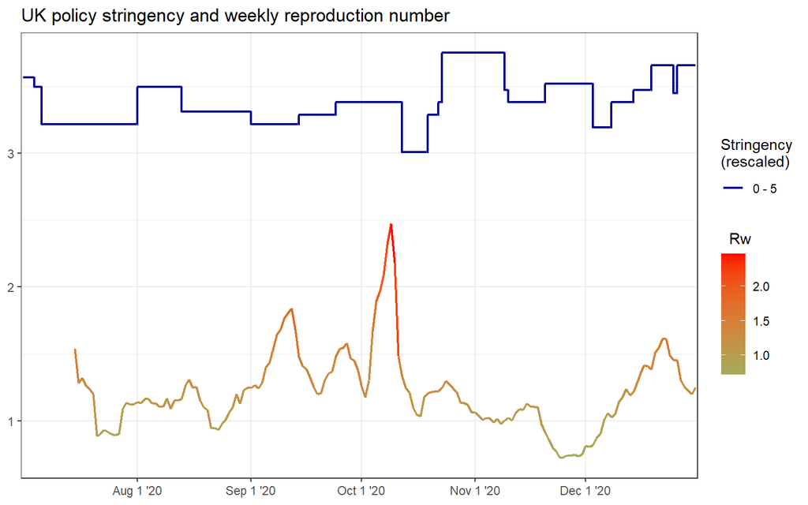

```r
# Make UK time series dataset
covid_uk <- covid_df %>%
  filter(country_code == "GBR")

# Plot UK's stringency and Rw
ggplot(covid_uk, aes(x = date_value, group = 1)) +
  geom_step(aes(y = stringency / 20, alpha = stringency), color = "darkblue", size = 0.75) +
  geom_line(aes(y = rw, color = rw), size = 0.75) +

  # Adapt x-axis labels
  scale_x_discrete(breaks = c("2020-08-01", "2020-09-01", "2020-10-01", "2020-11-01", "2020-12-01", "2021-01-01"),
                   labels = c("Aug 1 '20", "Sep 1 '20", "Oct 1 '20", "Nov 1 '20", "Dec 1 '20", "Jan 1 '21")) +

  # Add faux alpha range to create legend for Stringency
  scale_alpha(range = 1, breaks = 70, labels = "0 - 5", name = "Stringency\n(rescaled)") +

  # Define gradient for Rw from green to red, so that around Rw = 1 is where shift between green and orange occurs
  scale_color_gradient2(mid = "seagreen3", high = "red", name = "  Rw") +

  # Clean up theme
  theme_bw() +
  theme(axis.title = element_blank()) +

  # Set legend positions to be close to their respective lines
  guides(alpha = guide_legend(order = 1)) +

  # Set plot title
  labs(title = "UK policy stringency and weekly reproduction number")
```

### Exercise 8 (18 points)

In 1918 and 1919, the world had to cope with three waves of a global pandemic, the Spanish Flu. The attached figure shows historical infections in New York, Berlin, and Paris. With the NYT Archive and the two data frames for 1918 and 1919 that you downloaded with your function from Exercise 4, you have the chance to study the “influenza” and its effect on societies at that time, public discussion about it, measures taken against it, etc. In this exercise, explore, discuss, and visualise information from the archive about this historical pandemic (e.g. with time series plots of word counts, with word clouds of selected articles, by depicting articles, or any other approach). For this you can use `quanteda`, the `tidyverse`, or any other package. For example, do you find discussion of similar policy measures as the ones taken at the moment? Were there articles early in 1918 that seem to have underestimated the threat? Feel free to explore whatever question and topics about the pandemic you find most interesting. You can use all data from the NYT archive of these years and also use further data sources with references if helpful.

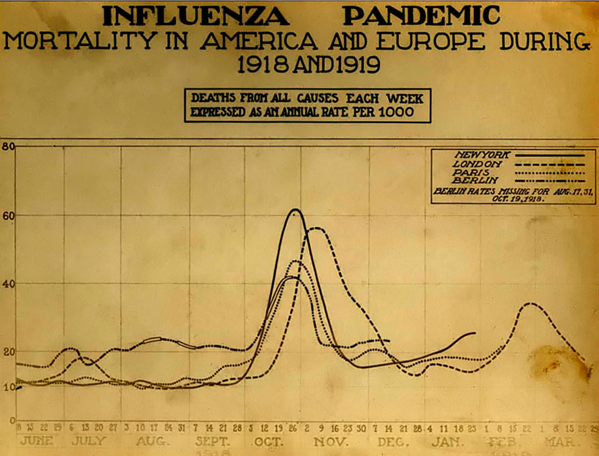

Image source: https://en.wikipedia.org/wiki/Spanish_flu

Hint 1: When initially exploring the downloaded data for 1918 and 1919, you can also have a look at the `.csv` files/search through them in Excel or similar programs. If the files are too large and slow to load, you can delete some columns that you do not need for your analysis in R before saving the `.csv` files.

Hint 2: As the free archive only returns articles up to one paragraph length, you can use the `texts_combined` column in your analysis when helpful if you want to make use of more available textual information. You can also have a look at the abstract column which contains some more texts during the years 1918 and 1919 than the `snippet` column.

**I wanted to see if a time series plot of pandemic keywords published in the NYT would mirror the mortality plot above. I looked at words related to the Spanish flu pandemic that were published in the headline or snippet. I excluded words that could have been used in many other contexts at the time, such as ‘cases’ or ‘deaths’. The keyword plot clearly shows a major spike coinciding with New York’s first mortality wave during the autumn of 1918. The keyword plot peaks a bit sooner than mortalities though. This may be due to a combination of reasons, for instance; a) the new disease coming to town and taking hold could be considered more “news-worthy” by editors than the continued reporting of infections and deaths; b) as the pandemic continued, words normally used more broadly such as the before-mentioned ‘cases’ or ‘deaths’ may have become self-explanatory in headlines and snippets, reducing the need for giving context until the full article. Therefore, there may be a higher risk that I’ve underestimated pandemic keywords later in the wave compared to earlier.**

**Subsequent waves during 1919 in the USA or abroad do not show up however. In fact, the NYT did not seem to report on the pandemic with great intensity in general. Over the two years, only 0.41% of articles contained at least one keyword in the headline or snippet. During Jan and Feb 1918, the two months prior to the first known major outbreak on Mar 4th (source: https://en.wikipedia.org/wiki/Spanish_flu), 0.37% of headline-snippet combos contained one or more of the chosen keywords. Even during the main months of reporting, Aug to Dec 1918, that number only rose to 1.02%. Some of the low reporting intensity could possibly be due to World War 1 censorship (for morale reasons) (ibid.), but that doesn’t explain the lack of reporting in 1919.**

**To close, I read through some of the articles and drew out one of the headline-snippet combos with the most keywords from the start of the main wave. It describes a Norwegian liner arriving in New York with 4 passengers dead from the Spanish flu and 200 having been ill - a very similar picture to the cruise ships that were outbreak centres during the early days of the Covid-19 pandemic.**

```r
# Load CSV files with NYT article info for 1918 and 1919
nyt1918 <- read.csv("nyt1918.csv", stringsAsFactors = FALSE)
nyt1919 <- read.csv("nyt1919.csv", stringsAsFactors = FALSE)

# Bind data frames into one
nyt_all <- bind_rows(nyt1918, nyt1919)

# Add doc_id variable so data frame can be joined with analysis data later
nyt_all <- nyt_all %>%
  mutate(doc_id = c(""))

for (i in 1:nrow(nyt_all)) {
  nyt_all[i, "doc_id"] <- paste0("text", i)
}
```

```r
# Create a corpus of texts_combined from the two NYT data frames
nyt_corpus <- corpus(nyt_all$text_combined)

# Create dfm based on corpus
nyt_dfm <- dfm(nyt_corpus, remove_punct = TRUE)

# Create dictionary with words related to the Spanish flu pandemic (words were added or removed after initial exploration of articles with some of these words; for instance, 'masks' was removed due to seemingly more mentions related to WW1 gas masks)
flu_dict <- dictionary(list(spanish_flu = c("contagion", "contagious", "disease", "epidemic", "flu", "infected", "infections", "infectious", "influenza", "lockdown", "pandemic", "plauge", "pneumonia", "pneumonic", "quarantine", "vaccine")))

# Create tibble with number of pandemic keywords in each combined text
nyt_flu <- dfm_lookup(nyt_dfm, flu_dict) %>%
  as_tibble() %>%

  # Join with article data
  inner_join(nyt_all, by = "doc_id")

# Percent of articles with at least one pandemic keyword in combined text
nyt_flu %>%
  filter(spanish_flu != 0) %>%
  nrow() * 100 / nrow(nyt_flu)
```

```
## [1] 0.4099984
```

```r
# Make tibble of article data in Jan & Feb 1918
nyt_no_flu <- nyt_flu %>%
  filter(pub_date >= "1918-01-01" & pub_date <= "1918-02-28")

# Percent of articles with at least one pandemic keyword in combined text BEFORE DISEASE SPREAD
nyt_no_flu %>%
  filter(spanish_flu != 0) %>%
  nrow() * 100 / nrow(nyt_no_flu)
```

```
## [1] 0.3684662
```

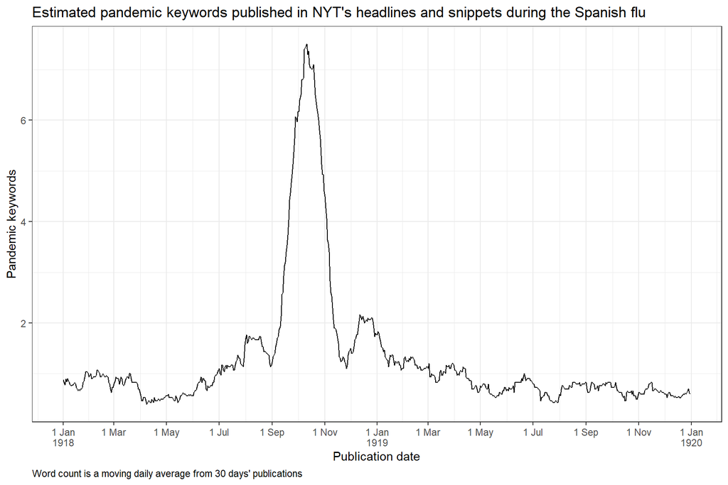

```r
# Convert pub_date variable to Date type
nyt_flu$pub_date <- as.Date(nyt_flu$pub_date)

# Create tibble with moving average of estimated number of pandemic keywords per date
nyt_flu_ts <- nyt_flu %>%
  group_by(pub_date) %>%
  summarise(flu_words = sum(spanish_flu)) %>%

  # 30-day moving average to smooth out noise on plot (this moving average is centered, unlike in Exercise 7, so it includes days on either side of date, instead of just including prior dates)
  mutate(m30d_avg_flu = rollapplyr(flu_words, 30, mean, align = "center", partial = TRUE))

# Plot estimated number of pandemic keywords as time series
ggplot(nyt_flu_ts, aes(pub_date, m30d_avg_flu, group = 1)) +
  geom_line() +
  scale_x_date(name = "Publication date",
               date_breaks = "2 months",

               # Label x-axis. First label here appears last on plot for some reason.
               date_labels = c("1 Jan\n1920","1 Jan\n1918", "1 Mar", "1 May", "1 Jul", "1 Sep", "1 Nov",
                               "1 Jan\n1919", "1 Mar", "1 May", "1 Jul", "1 Sep", "1 Nov")) +
  ylab("Pandemic keywords") +
  labs(title = "Estimated pandemic keywords published in NYT's headlines and snippets during the Spanish flu",
       caption = "Word count is a moving daily average from 30 days' publications") +
  theme_bw() +

  # Position caption on left-hand side
  theme(plot.caption = element_text(hjust = 0))
```

```r
# Make tibble of article data from Aug to Dec 1918
nyt_flu_months <- nyt_flu %>%
  filter(pub_date >= "1918-08-01" & pub_date <= "1918-12-31")

# Percent of articles with at least one pandemic keyword in combined text during Aug to Dec 1918
nyt_flu_months %>%
  filter(spanish_flu != 0) %>%
  nrow() * 100 / nrow(nyt_flu_months)
```

```
## [1] 1.023631
```

```r
# Print pub_date and text_combined of article with most pandemic keywords (there are 3 tied for most keywords; printing earliest)
nyt_flu %>%
  filter(spanish_flu == max(spanish_flu)) %>%
  filter(pub_date == min(pub_date)) %>%
  select(pub_date) %>%
  first()
```

```
## [1] "1918-08-14"
```

```r
nyt_flu %>%
  filter(spanish_flu == max(spanish_flu)) %>%
  filter(pub_date == min(pub_date)) %>%
  select(text_combined) %>%
  first()
```

```
## [1] "SPANISH INFLUENZA HERE, SHIP MEN SAY; Officers of Norwegian Liner Attribute Four Deaths During Voyage to the Disease.10 OTHER PASSENGERS ILL Brooklyn Doctor Who Is Treating Them Says They AreSuffering with Pneumonia. 200 Passengers Ill at One Time. SPANISH INFLUENZA HERE, SHIP MEN SAY Health…
```